# Creative Assignment One

Whytne Stevens

9/13/2020

# Creative Assignment 1

For this assignment, I am looking at the same question I am looking at for Quant: how one’s profession and English language might effect their income and income to poverty ratio. Lik in quant, I am narrowing down my analysis to person level data for Dallas County, Texas from Public Use Microdata Sample (PUMAs) provided by the 2018 1 year American Community Survey and have selected the following variables to explore this question:

Sex (SEX) (categorical)

Standard Occupational Classification (SOCP) (categorical)

English ability (ENG) (categorical)

Language other than English spoken at home (LANX) (categorical)

Income (PINCP) (continuous)

Work hours per week (WKHP) (continuous)

Income-to-poverty ratio (POVPIP) (continuous)

```r
library(ggplot2)
library(tidycensus)
library(tidyverse)
library(ggthemes)
library(GGally)
library(ggcorrplot)
suppressPackageStartupMessages(library(tidyverse))
```

```r
person_vars_2018 <- pums_variables %>%
  distinct(year, survey, var_code,
           var_label, data_type, level) %>%
  filter(level == "person", year == 2018, survey == "acs1")
```

```r
area_vars_2018 <- load_variables(2018, "acs1")
```

```r
dallas_county <- c("02301", "02302", "02303", "02304", "02308", "02317", "02318", "02319", "02320", "02321", "02322")
```

```r
person_data <- get_pums(variables = c("PUMA",
                                      "RAC1P",
                                      "SEX",
                                      "SOCP",
                                      "LANX",
                                      "ENG",
                                      "PINCP",
                                      "WKHP",
                                      "POVPIP"),
                        state = "TX",
                        year = 2018,
                        survey = "acs1",
                        recode = TRUE) %>%
  mutate(SOCP = as.numeric(SOCP)) %>%
  filter(PUMA == dallas_county,
         PINCP > 0,
         SOCP > 0,
         WKHP > 0,
         POVPIP > 0) %>%
  select(RAC1P_label, SEX_label, SOCP_label, ENG_label, LANX_label, PINCP, WKHP, POVPIP)
```

## Relationships and Distributions of Continuous Variables

Here, I began exploring the relationships and distributions between my continuous variables, which were Total person’s income (PINCP), hours worked per week (WKHP), and income to poverty ratio (POVPIP). In the charts below, I used scatterplots and sorted most of the variables by English language ability/proficiency

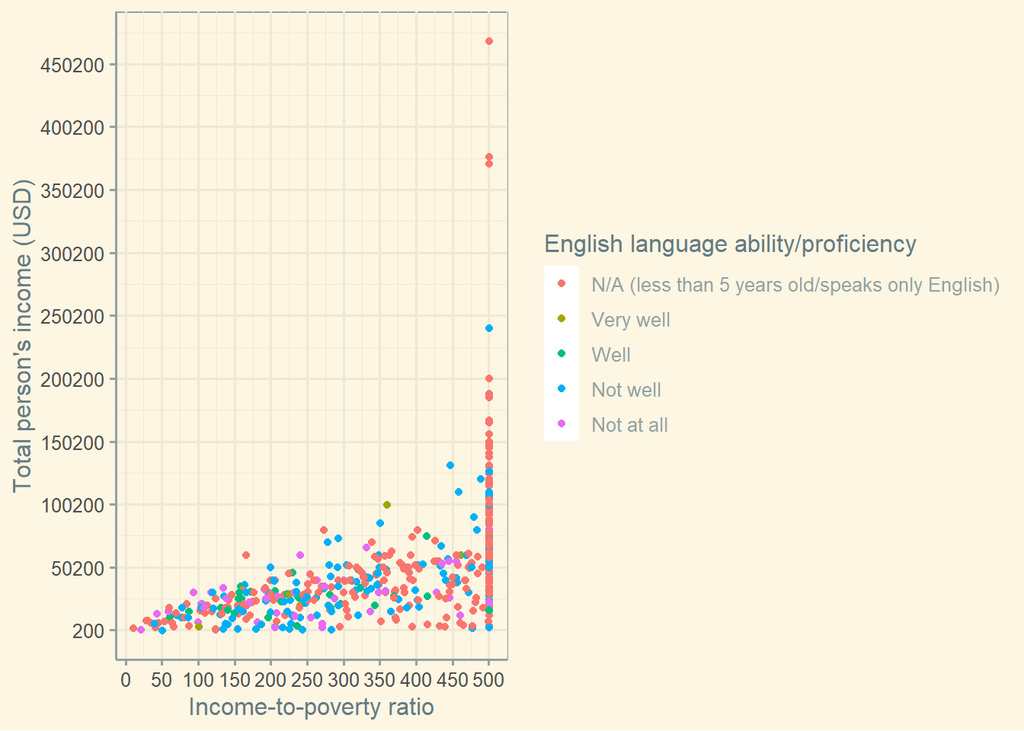

```r
ggplot(person_data,
       aes(x = POVPIP,
           y = PINCP,
           color = ENG_label)) +
  geom_point() +
  scale_x_continuous(name = "Income-to-poverty ratio",
                     breaks = seq(0, 500, by = 50),
                     labels = paste(seq(0, 500, by = 50), "", sep = "")) +
  scale_y_continuous(name = "Total person's income (USD)",
                     breaks = seq(200, 500000, by = 50000)) +
  scale_color_discrete(name = "English language ability/proficiency",
                       labels = c("N/A (less than 5 years old/speaks only English)",
                                  "Very well",
                                  "Well",
                                  "Not well",
                                  "Not at all")) +
  theme_solarized()
```

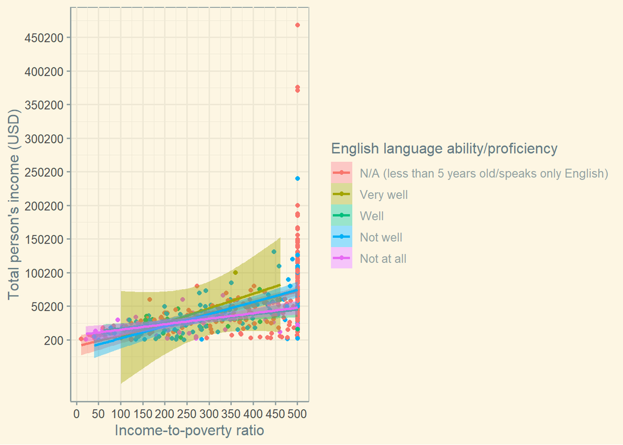

```r
ggplot(person_data,
       aes(x = POVPIP,
           y = PINCP,
           color = ENG_label,
           fill = ENG_label)) +
  geom_point() +
  stat_smooth(method = "lm") +
  scale_x_continuous(name = "Income-to-poverty ratio",
                     breaks = seq(0, 500, by = 50),
                     labels = paste(seq(0, 500, by = 50), "", sep = "")) +
  scale_y_continuous(name = "Total person's income (USD)",
                     breaks = seq(200, 500000, by = 50000)) +
  scale_color_discrete(name = "English language ability/proficiency",
                       labels = c("N/A (less than 5 years old/speaks only English)",
                                  "Very well",
                                  "Well",
                                  "Not well",
                                  "Not at all")) +
  scale_fill_discrete(name = "English language ability/proficiency",
                       labels = c("N/A (less than 5 years old/speaks only English)",
                                  "Very well",
                                  "Well",
                                  "Not well",
                                  "Not at all")) +
  theme_solarized()
```

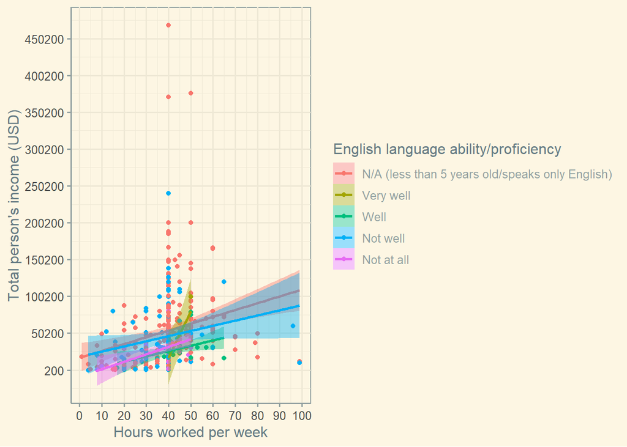

```r
ggplot(person_data,
       aes(x = WKHP,
           y = PINCP,
           color = ENG_label,
           fill = ENG_label)) +
  geom_point() +
  stat_smooth(method = "lm") +
  scale_x_continuous(name = "Hours worked per week",
                     breaks = seq(0, 100, by = 10),
                     labels = paste(seq(0, 100, by = 10), "", sep = "")) +
  scale_y_continuous(name = "Total person's income (USD)",
                     breaks = seq(200, 500000, by = 50000)) +
  scale_color_discrete(name = "English language ability/proficiency",
                       labels = c("N/A (less than 5 years old/speaks only English)",
                                  "Very well",
                                  "Well",
                                  "Not well",
                                  "Not at all")) +
  scale_fill_discrete(name = "English language ability/proficiency",
                       labels = c("N/A (less than 5 years old/speaks only English)",
                                  "Very well",
                                  "Well",
                                  "Not well",
                                  "Not at all")) +
  theme_solarized()
```

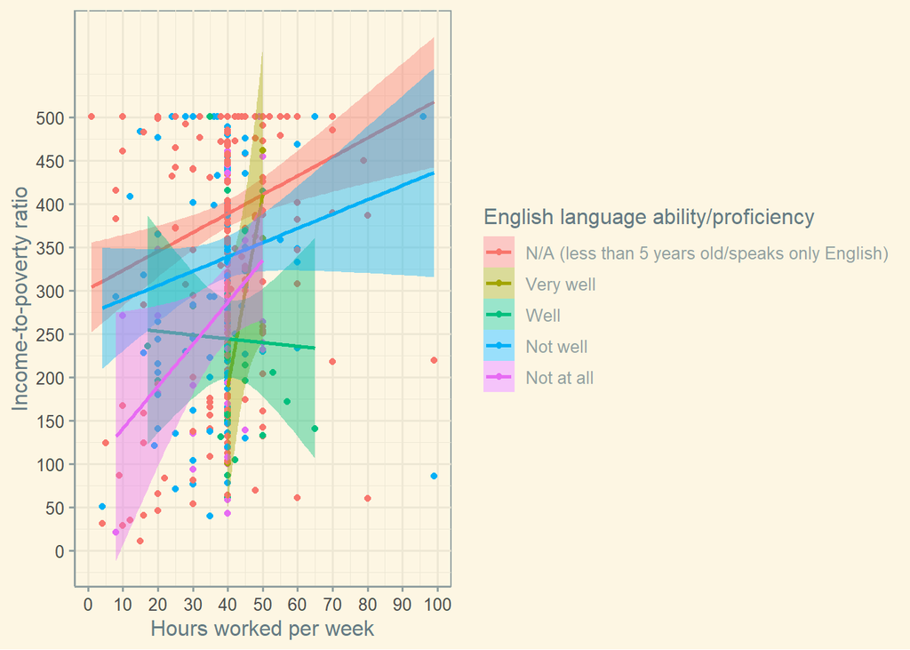

```r
ggplot(person_data,
       aes(x = WKHP,
           y = POVPIP,
           color = ENG_label,
           fill = ENG_label)) +
  geom_point() +
  stat_smooth(method = "lm") +
 scale_x_continuous(name = "Hours worked per week",
                     breaks = seq(0, 100, by = 10),
                     labels = paste(seq(0, 100, by = 10), "", sep = "")) +
  scale_y_continuous(name = "Income-to-poverty ratio",
                     breaks = seq(0, 500, by = 50)) +
  scale_color_discrete(name = "English language ability/proficiency",
                       labels = c("N/A (less than 5 years old/speaks only English)",
                                  "Very well",
                                  "Well",
                                  "Not well",
                                  "Not at all")) +
  scale_fill_discrete(name = "English language ability/proficiency",
                       labels = c("N/A (less than 5 years old/speaks only English)",
                                  "Very well",
                                  "Well",
                                  "Not well",
                                  "Not at all")) +
  theme_solarized()
```

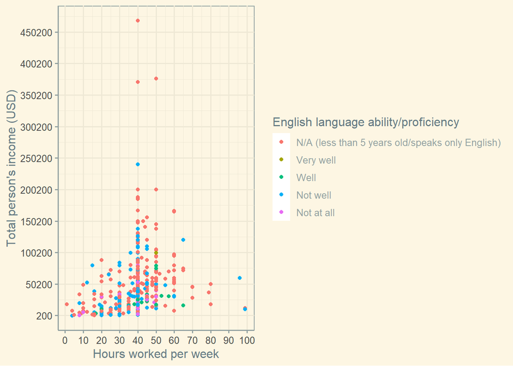

```r
ggplot(person_data,
       aes(x = WKHP,
           y = PINCP,
           color = ENG_label)) +
  geom_point() +
  scale_x_continuous(name = "Hours worked per week",
                     breaks = seq(0, 100, by = 10),
                     labels = paste(seq(0, 100, by = 10), "", sep = "")) +
  scale_y_continuous(name = "Total person's income (USD)",
                     breaks = seq(200, 500000, by = 50000)) +
  scale_color_discrete(name = "English language ability/proficiency",
                       labels = c("N/A (less than 5 years old/speaks only English)",
                                  "Very well",
                                  "Well",
                                  "Not well",
                                  "Not at all")) +
  theme_solarized()
```

[figure not shown]

```r
ggplot(person_data,
       aes(x = PINCP,
           y = POVPIP,
           color = ENG_label,
           fill = ENG_label)) +
  geom_point() +
  stat_smooth(method = "lm") +
    scale_x_continuous(name = "Total person's income (USD)",
                     breaks = seq(200, 500000, by = 50000,
                     labels = paste(seq(200, 500000, by = 50000), "$", sep = "")) +
  scale_y_continuous(name = "Income-to-poverty ratio",
                     breaks = seq(0, 500, by = 50))) +
  scale_color_discrete(name = "English language ability/proficiency",
                       labels = c("N/A (less than 5 years old/speaks only English)",
                                  "Very well",
                                  "Well",
                                  "Not well",
                                  "Not at all")) +
  scale_fill_discrete(name = "English language ability/proficiency",
                       labels = c("N/A (less than 5 years old/speaks only English)",
                                  "Very well",
                                  "Well",
                                  "Not well",
                                  "Not at all")) +
  theme_solarized()
```

I then began to explore the relationships and distributions between my continuous variables, which were Total person’s income (PINCP), hours worked per week (WKHP), and income to poverty ratio (POVPIP), by using scatterplots as well

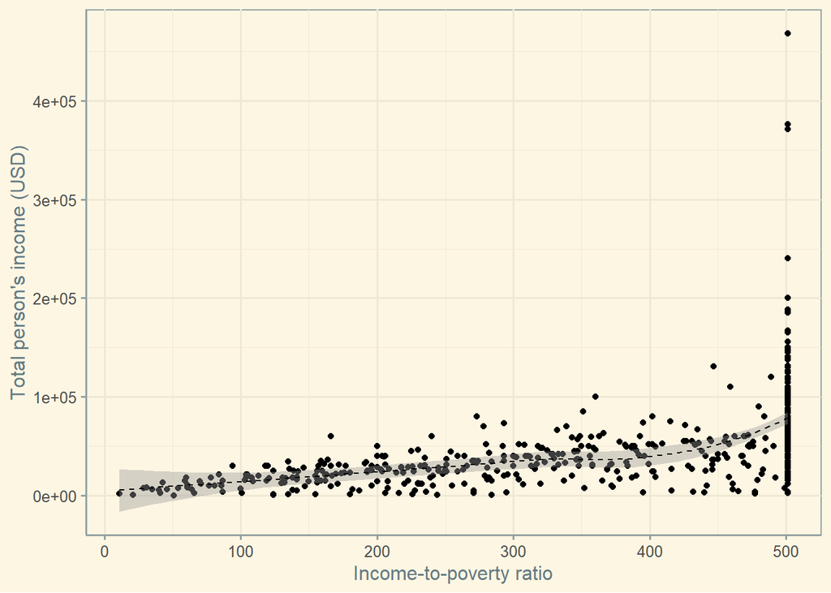

```r
ggplot(person_data,
       aes(x = POVPIP,
           y = PINCP)) +
  geom_point() +
  stat_smooth(color = "black", linetype = 2, size = 0.5) +
  scale_x_continuous(name = "Income-to-poverty ratio") +
  scale_y_continuous(name = "Total person's income (USD)") +
  theme_solarized()
```

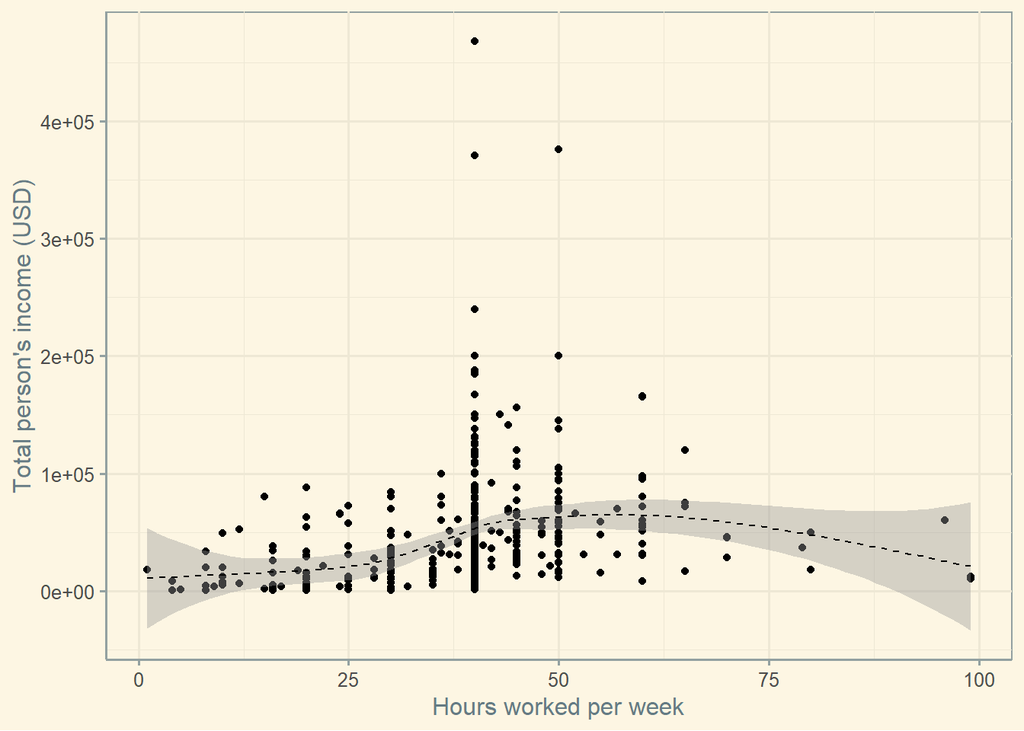

```r
ggplot(person_data,
       aes(x = WKHP,
           y = PINCP)) +
  geom_point() +
  stat_smooth(color = "black", linetype = 2, size = 0.5) +
  scale_x_continuous(name = "Hours worked per week") +
  scale_y_continuous(name = "Total person's income (USD)") +
  theme_solarized()
```

## Relationships and Distributions of Categorical Variables

Below is a bar chart showing the distributions of English language proficiency by racial groups

[figure not shown]

```r
ggplot(person_data, aes(x = RAC1P_label, fill = ENG_label)) +
  geom_bar() +
  scale_y_continuous(name = "English language ability/proficiency") +
  scale_x_discrete(name = "Race",
                       labels = c("American Indian\n alone",
                                  "American Indian and Alaska Native tribes specified;\n or American Indian or Alaska Native,\n not specified and no other races",
                                  "Asian \n alone",
                                  "Black \n alone",
                                  "Native Hawaiian and \n Other Pacific Islander alone",
                                  "Some Other\n Race alone",
                                  "Two or \n More Races",
                                  "White \n alone")) +
  scale_fill_discrete(name = element_blank(),
                        labels = c("N/A (less than 5 years old/speaks only English)",
                                  "Very well",
                                  "Well",
                                  "Not well",
                                  "Not at all")) +
  theme_solarized()
```

I also tried using a density plot to further analyze my ENG and LANX variables

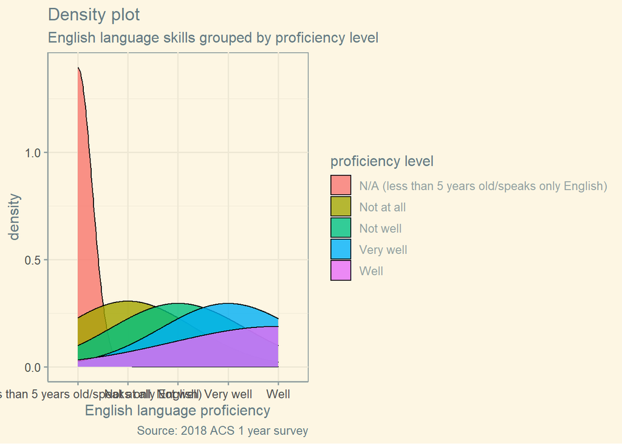

```r
ggplot(person_data, aes(ENG_label))+
 geom_density(aes(fill=factor(ENG_label)), alpha=0.8) +
    labs(title="Density plot",
         subtitle="English language skills grouped by proficiency level",
         caption="Source: 2018 ACS 1 year survey",
         x="English language proficiency",
         fill="proficiency level") +
 theme_solarized()
```

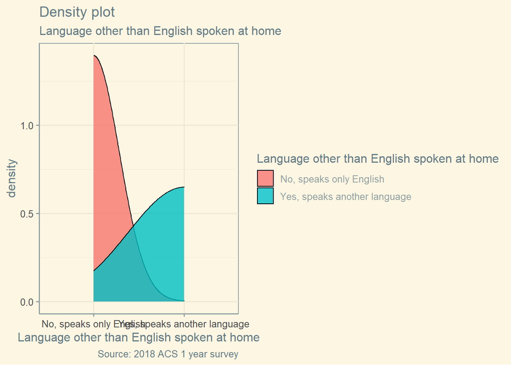

```r
ggplot(person_data, aes(LANX_label))+
 geom_density(aes(fill=factor(LANX_label)), alpha=0.8) +
    labs(title="Density plot",
         subtitle="Language other than English spoken at home",
         caption="Source: 2018 ACS 1 year survey",
         x="Language other than English spoken at home",
         fill="Language other than English spoken at home") +
 theme_solarized()
```

## Relationships and Distributions of Categorical and Continuous Variables

I also tried some violin plots, jitter plots, and box plots to see if an interesting story could be told from the distribution of the data points for my income, income to poverty ratio, and hours worked per week variables in relation to one’s English proficiency

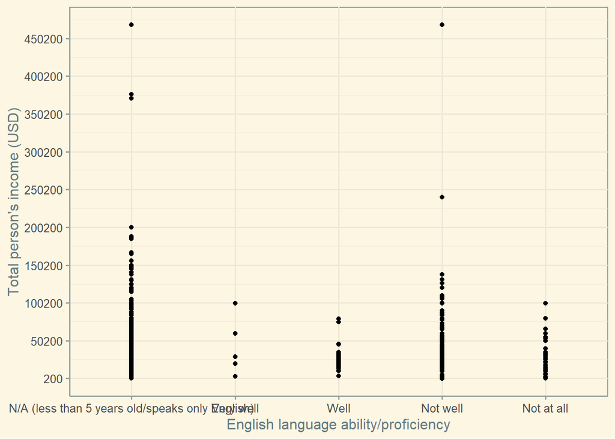

```r
ggplot(person_data,
       aes(x = ENG_label,
           y = PINCP)) +
  geom_point() +
  scale_x_discrete(name = "English language ability/proficiency",
                        labels = c("N/A (less than 5 years old/speaks only English)",
                                  "Very well",
                                  "Well",
                                  "Not well",
                                  "Not at all")) +
  scale_y_continuous(name = "Total person's income (USD)",
                     breaks = seq(200, 500000, by = 50000)) +
  theme_solarized()
```

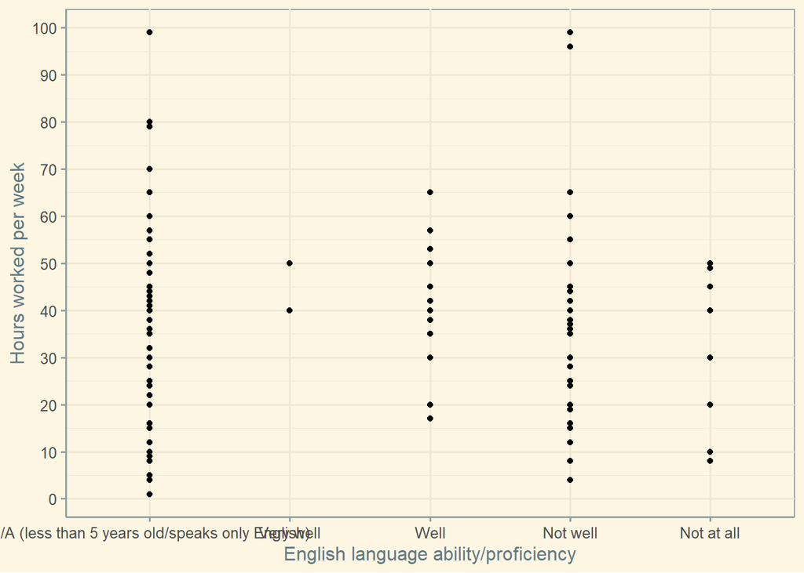

```r
ggplot(person_data,
       aes(x = ENG_label,
           y = WKHP)) +
  geom_point() +
  scale_x_discrete(name = "English language ability/proficiency",
                        labels = c("N/A (less than 5 years old/speaks only English)",
                                  "Very well",
                                  "Well",
                                  "Not well",
                                  "Not at all")) +
  scale_y_continuous(name = "Hours worked per week",
                     breaks = seq(0, 100, by = 10)) +
  theme_solarized()
```

I also tried some violin plots, jitter plots, and box plots to see if an interesting story could be told from the variables I chose for this section and the distribution of those data points

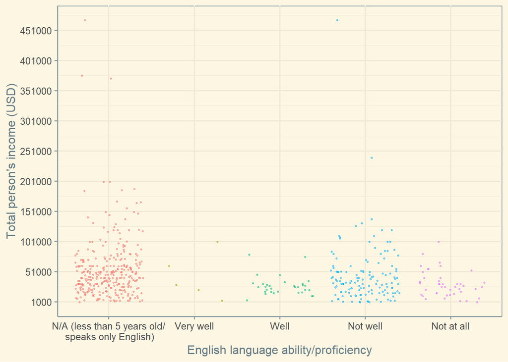

```r
ggplot(person_data,
       aes(x = ENG_label,
           y = PINCP,
           color = ENG_label)) +
  geom_point(position = "jitter",
             size = 0.5,
             alpha = 0.5) +
  scale_x_discrete(name = "English language ability/proficiency",
                        labels = c("N/A (less than 5 years old/\n speaks only English)",
                                  "Very well",
                                  "Well",
                                  "Not well",
                                  "Not at all")) +
 scale_y_continuous(name = "Total person's income (USD)",
                     breaks = seq(1000, 500000, by = 50000))  +
  theme_solarized() +
  theme(legend.position = "none")
```

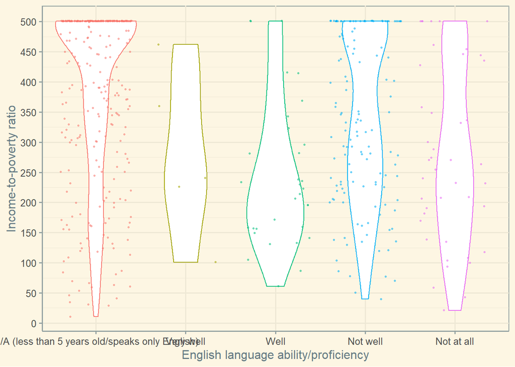

```r
ggplot(person_data,
       aes(x = ENG_label,
           y = POVPIP,
           color = ENG_label)) +
  geom_violin() +
  geom_point(position = "jitter",
             alpha = 0.5,
             size = 0.5) +
  scale_x_discrete(name = "English language ability/proficiency",
                        labels = c("N/A (less than 5 years old/speaks only English)",
                                  "Very well",
                                  "Well",
                                  "Not well",
                                  "Not at all")) +
  scale_y_continuous(name = "Income-to-poverty ratio",
                     breaks = seq(0, 500, by = 50)) +
  theme_solarized() +
  theme(legend.position = "none")
```

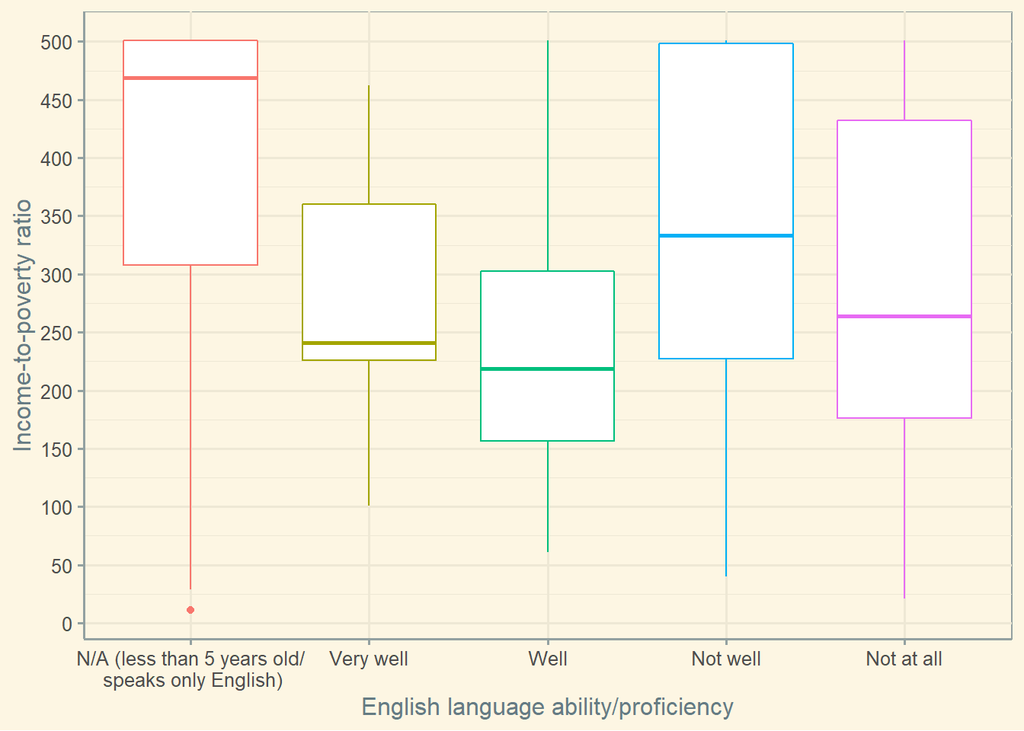

```r
ggplot(person_data,
       aes(x = ENG_label,
           y = POVPIP,
           color = ENG_label)) +
  geom_boxplot() +
  scale_x_discrete(name = "English language ability/proficiency",
                        labels = c("N/A (less than 5 years old/\n speaks only English)",
                                  "Very well",
                                  "Well",
                                  "Not well",
                                  "Not at all")) +
  scale_y_continuous(name = "Income-to-poverty ratio",
                     breaks = seq(0, 500, by = 50))  +
  theme_solarized() +
  theme(legend.position = "none")
```

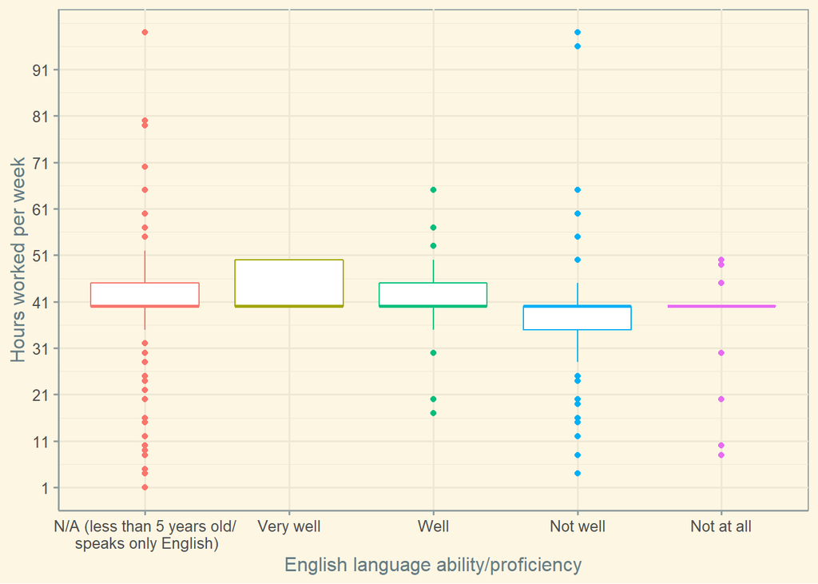

```r
ggplot(person_data,
       aes(x = ENG_label,
           y = WKHP,
           color = ENG_label)) +
  geom_boxplot() +
  scale_x_discrete(name = "English language ability/proficiency",
                        labels = c("N/A (less than 5 years old/\n speaks only English)",
                                  "Very well",
                                  "Well",
                                  "Not well",
                                  "Not at all")) +
  scale_y_continuous(name = "Hours worked per week",
                     breaks = seq(1, 100, by = 10)) +
  theme_solarized() +
  theme(legend.position = "none")
```

Lastly, I did try my hand at some correlograms. To the extent that they worked or were accurate, I am not sure. I had some technical errors that prevented me from including them in this assignment. However, I would like to come back to these types of charts in the future as I think they’d be useful in other data anaylses.